# Group Predictions

#### CBS Sports

This week we beat or tied 8 of 8 CBS Sports’ Experts.

For the season we are currently beating or tied with 8 of 8 CBS Sports’ Experts.

#### ESPN

We also beat or tied 10 of 10 ESPN Experts.

For the season we are currently beating or tied with 10 of 10 ESPN Experts.

### Win percentage for the week

[interactive chart not shown]

### Season Win Percentage

[interactive chart not shown]

### Games Correct

50

### Games Picked

76

### Number of predictions

78

This Week's Predictions

Week 5

| Game | Prediction | Winner | Correct | Correct Votes | Correct Percent |
| --- | --- | --- | --- | --- | --- |
| 1 | Washington Commanders | Chicago Bears | No | 6 | 0.0769 |
| 2 | Buffalo Bills | Jacksonville Jaguars | No | 7 | 0.0897 |
| 3 | Baltimore Ravens | Pittsburgh Steelers | No | 12 | 0.1538 |
| 4 | Detroit Lions | Detroit Lions | Yes | 78 | 1.0000 |
| 5 | Houston Texans | Atlanta Falcons | No | 26 | 0.3333 |
| 6 | New Orleans Saints | New Orleans Saints | Yes | 48 | 0.6154 |
| 7 | Miami Dolphins | Miami Dolphins | Yes | 78 | 1.0000 |
| 8 | Indianapolis Colts | Indianapolis Colts | Yes | 42 | 0.5385 |
| 9 | Cincinnati Bengals | Cincinnati Bengals | Yes | 45 | 0.5769 |
| 10 | Philadelphia Eagles | Philadelphia Eagles | Yes | 67 | 0.8590 |
| 11 | Kansas City Chiefs | Kansas City Chiefs | Yes | 74 | 0.9487 |
| 12 | New York Jets | New York Jets | Yes | 41 | 0.5256 |
| 13 | San Francisco 49ers | San Francisco 49ers | Yes | 66 | 0.8462 |
| 14 | Green Bay Packers | Las Vegas Raiders | No | 18 | 0.2308 |

[interactive chart not shown]

# Individual Predictions

#### Best Picks of the Week.

Antonio Mitchell, Anthony Bloss, James Tierney, DERRICK ELAM, Anthony Brinson, Robert Lynch, Melissa Printup

#### Best Season Correct Percentage

Justin Crick

#### Best Adjusted Season Correct Percentage

Justin Crick

- Adjusted season percentage accounts for the number of weeks picked.

## row

### Individual Table

Individual Results

Week 5

Name

Weekly # Correct

Percent

Weeks Picked

Season Percent

Adj Season Percent

Season Trend

Week 1

Week 2

Week 3

Week 4

Week 5

Antonio Mitchell

10

12

NA

11

10

0.7143

4

0.6935

0.5548

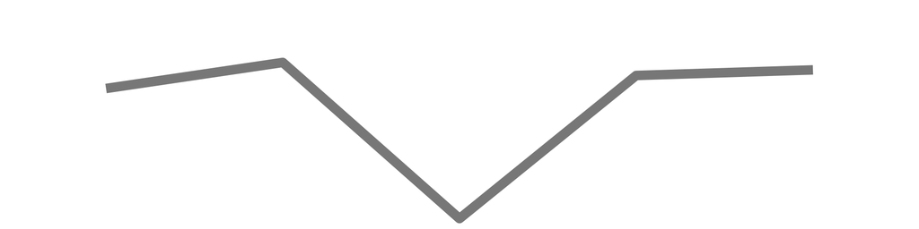

Anthony Bloss

8

10

11

12

10

0.7143

5

0.6711

0.6711

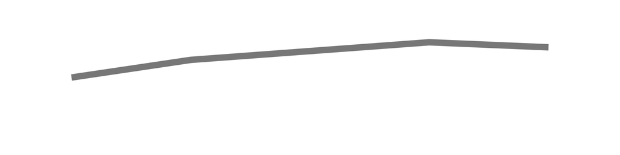

James Tierney

9

10

NA

10

10

0.7143

4

0.6290

0.5032

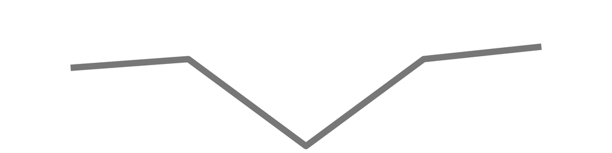

DERRICK ELAM

6

9

11

10

10

0.7143

5

0.6053

0.6053

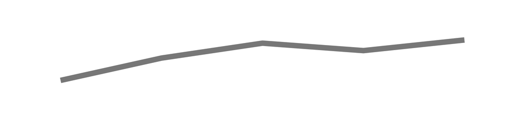

Anthony Brinson

10

11

8

6

10

0.7143

5

0.5921

0.5921

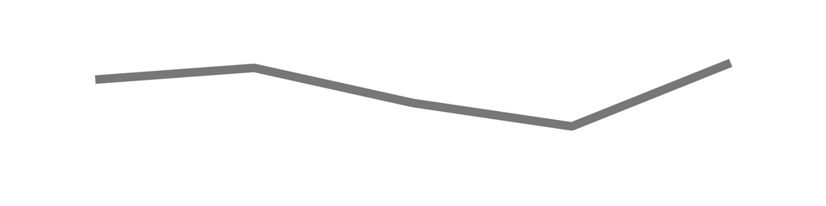

Robert Lynch

9

9

6

10

10

0.7143

5

0.5789

0.5789

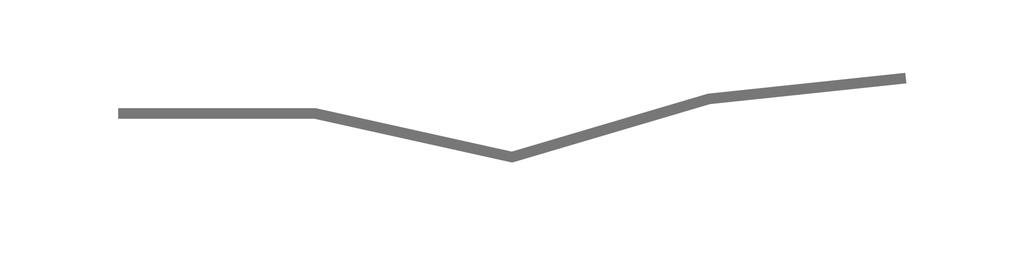

Melissa Printup

8

NA

8

7

10

0.7143

4

0.5500

0.4400

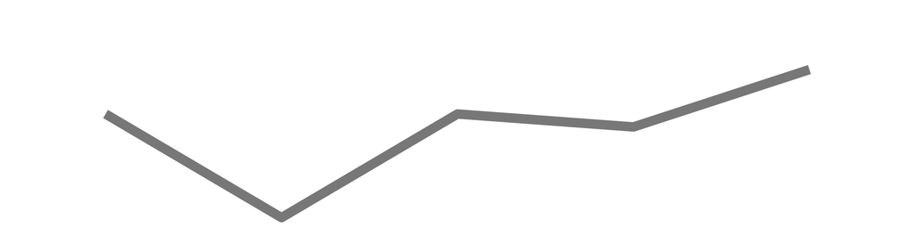

MICHAEL BRANSON

8

11

10

12

9

0.6429

5

0.6579

0.6579

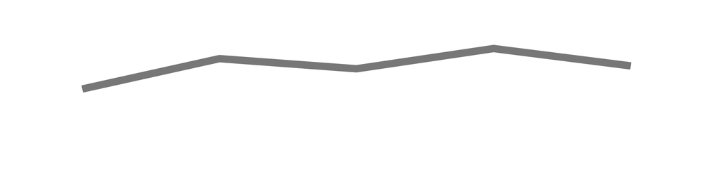

Cherylynn Vidal

10

9

9

12

9

0.6429

5

0.6447

0.6447

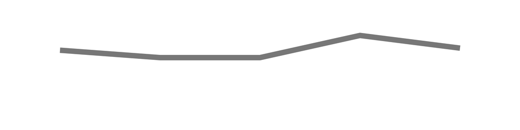

Aubrey Conn

9

12

8

11

9

0.6429

5

0.6447

0.6447

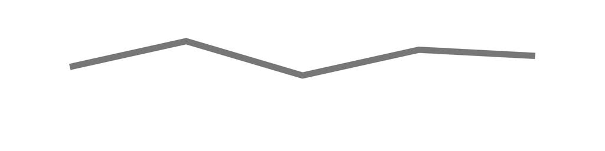

George Mancini

7

12

10

10

9

0.6429

5

0.6316

0.6316

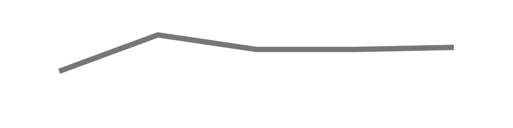

Jason Schattel

7

10

9

11

9

0.6429

5

0.6053

0.6053

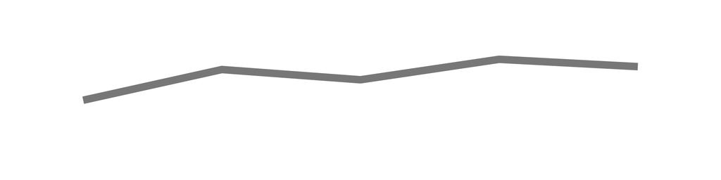

Bunnaro Sun

9

10

9

8

9

0.6429

5

0.5921

0.5921

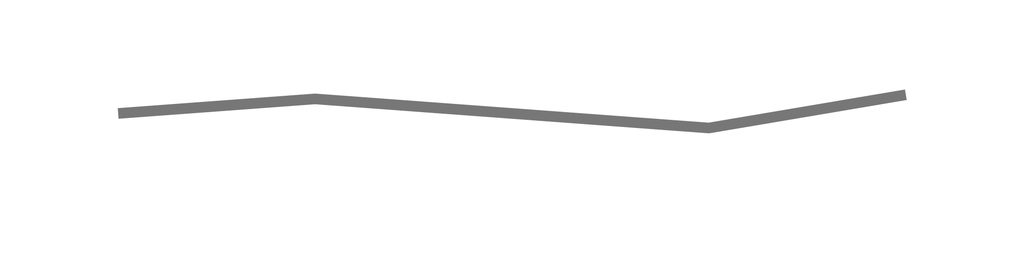

Amy Asberry

8

9

10

9

9

0.6429

5

0.5921

0.5921

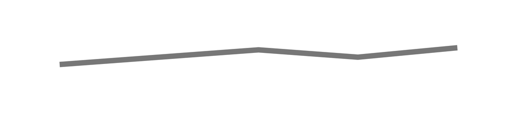

Matthew Schultz

8

NA

10

8

9

0.6429

4

0.5833

0.4666

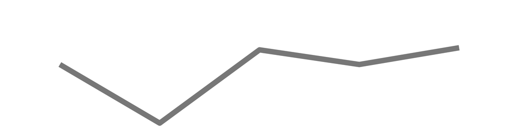

Charlene Redmer

9

9

NA

9

9

0.6429

4

0.5806

0.4645

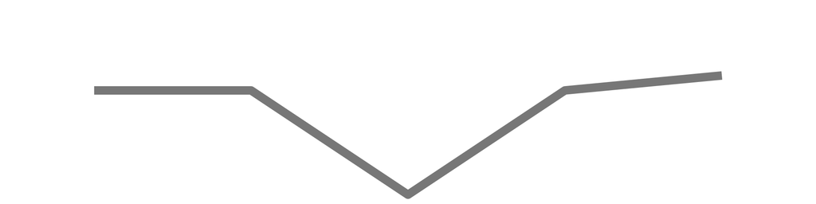

Robert Gelo

6

9

10

10

9

0.6429

5

0.5789

0.5789

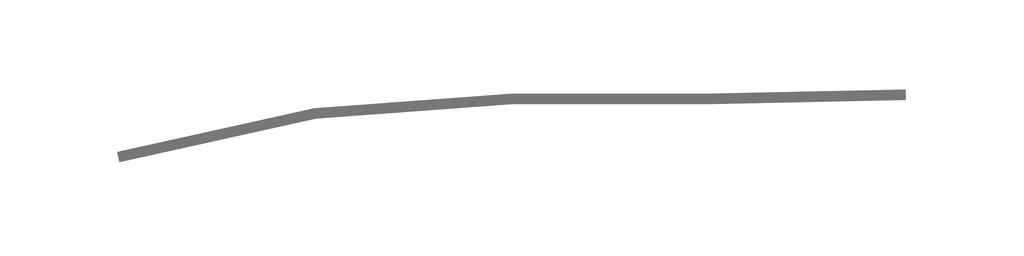

Robert Martin

10

9

6

NA

9

0.6429

4

0.5667

0.4534

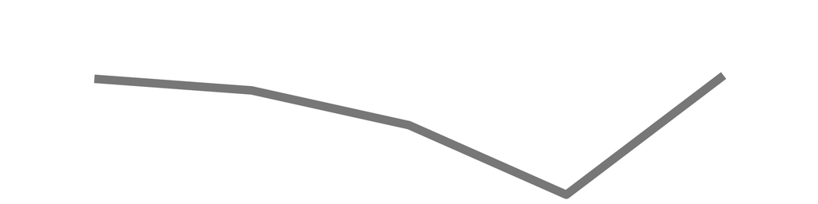

Justin Thrift

9

8

9

8

9

0.6429

5

0.5658

0.5658

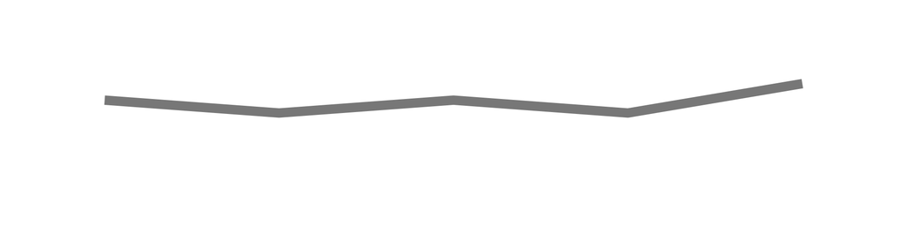

Montee Brown

7

NA

NA

9

9

0.6429

3

0.5435

0.3261

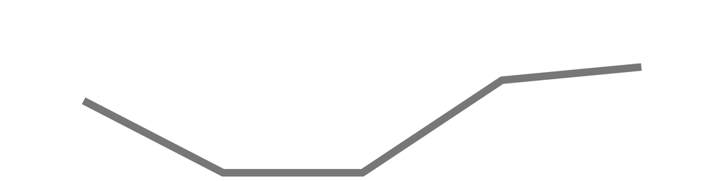

Brandon Parks

8

8

NA

NA

9

0.6429

3

0.5435

0.3261

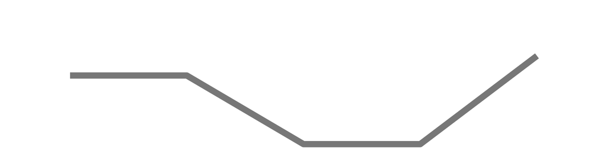

Steven Webster

8

8

6

8

9

0.6429

5

0.5132

0.5132

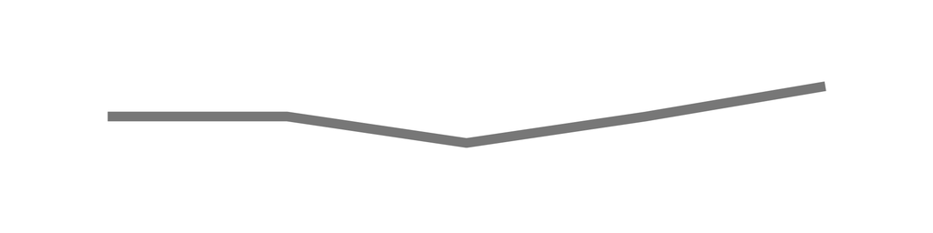

Justin Crick

11

11

11

13

8

0.5714

5

0.7105

0.7105

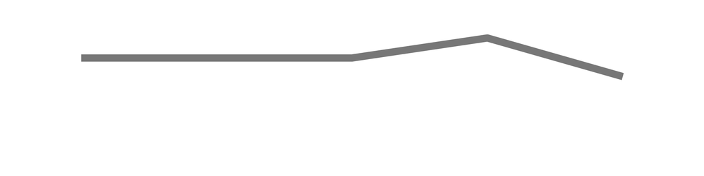

Ronald Schmidt

11

13

11

8

8

0.5714

5

0.6711

0.6711

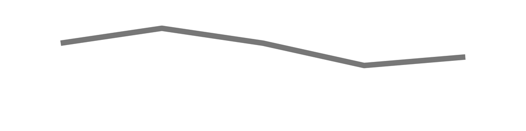

Chris Papageorge

11

11

11

10

8

0.5714

5

0.6711

0.6711

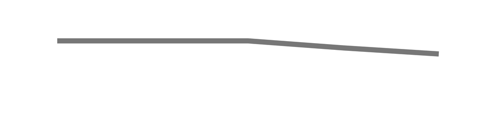

Sarah Sweet

9

12

12

9

8

0.5714

5

0.6579

0.6579

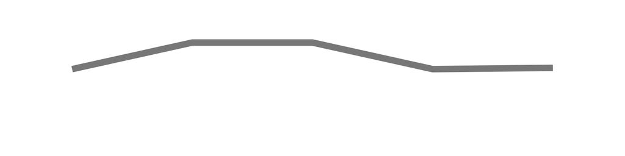

Ramar Williams

NA

11

11

9

8

0.5714

4

0.6500